# assignment2

10/8/2021

## overview

- I chose 2 worldwide datasets from 2005 to 2017, first dataset is about hdi (human development index), second dataset is about hapi (happiness score).
- Firstly, I want to explore the relationship between hdi and hapi, and see whether there are difference between different countries.
- Secondly, I want to explore the time trend of hdi or hapi, and see whether there are difference between different countries.

## compare hdi~hapi between two countries

- For example, we choose China and United States as indicators, and see whether the relationship of hdi and hapi is different between these two countries.

## ggplot

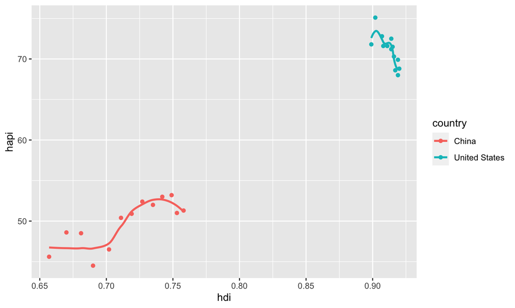

## What we can see from this plot?

- United States has a higher level of hdi and happiness score than China.
- In United States, when hdi increases, the happiness score decreases, the possible reason is at a high level of hdi, people do not worry about daily life, so when hdi increases, maybe they need to work harder to keep on the path, so the happiness score decreases.

## compare hdi or happiness trend between two countries

- We choose China and United States as indicators, and see whether the time tendency of hdi or hapi is different between these two countries.

## ggplot

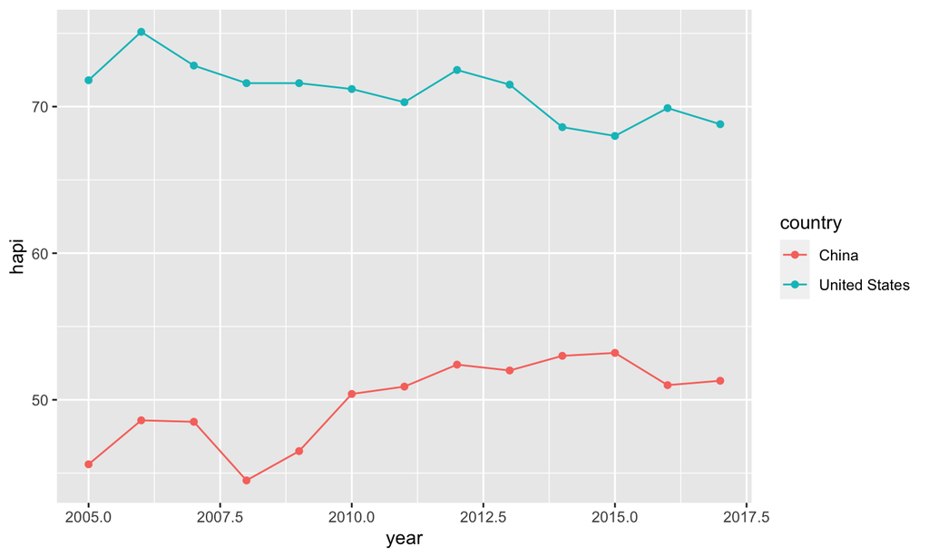